# iButton Temperature Data from 40 Aquatic Plots

Emily Watson-Cook, Jana Peirce

19 February 2022

Sensors were installed in the following locations in each pond:

- Water surface
- Above the moss layer
- At the sediment surface.

### Raw Data (99,720 rows)

[output not shown]

### Average Daily Temperature calculated (4320 rows)

| Date | iBtn ID | Plot ID | Sensor Type | Plot Type | Avg Daily Temp (°C) |
| --- | --- | --- | --- | --- | --- |
| 2021-07-19 | 1 | 21A-01 | Water surface | Aquatic forb | 20.1 |
| 2021-07-19 | 10 | 21A-03 | Sediment | Aquatic forb | 8.8 |
| 2021-07-19 | 101 | 21A-20 | Sediment | Lake | 15.7 |
| 2021-07-19 | 103 | 21A-21 | Water surface | Thick moss | 20.5 |
| 2021-07-19 | 105 | 21A-21 | Above moss | Thick moss | 20.8 |
| 2021-07-19 | 108 | 21A-21 | Sediment | Thick moss | 7.2 |

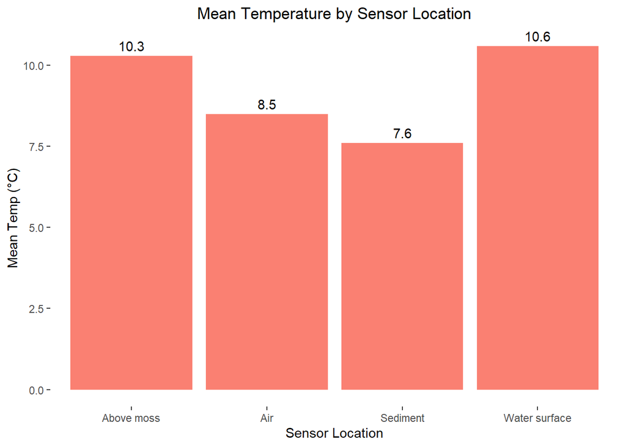

| Sensor Type | Mean Temp (°C) |
| --- | --- |
| Above moss | 10.3 |
| Air | 8.5 |
| Sediment | 7.6 |
| Water surface | 10.6 |

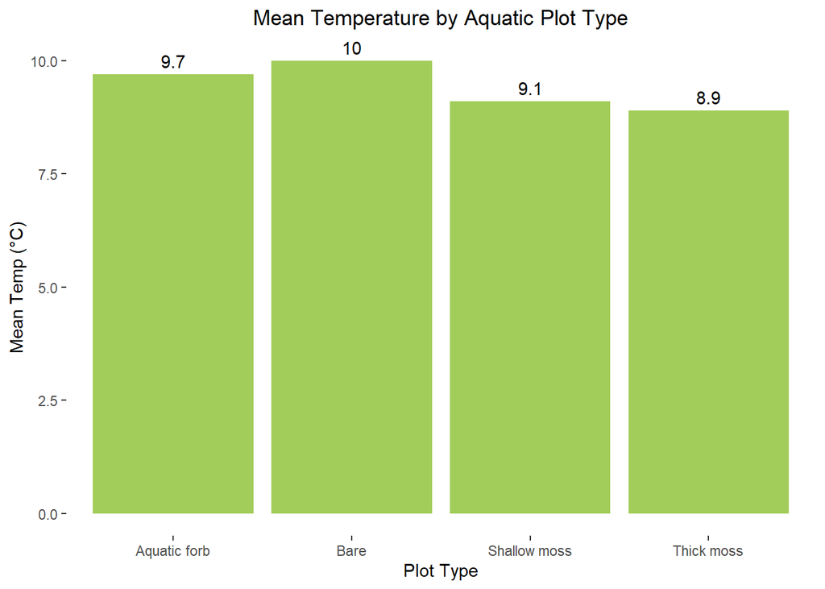

| Plot Type | Mean Temp (°C) |
| --- | --- |
| Aquatic forb | 9.7 |
| Bare | 10.0 |
| Shallow moss | 9.1 |
| Thick moss | 8.9 |

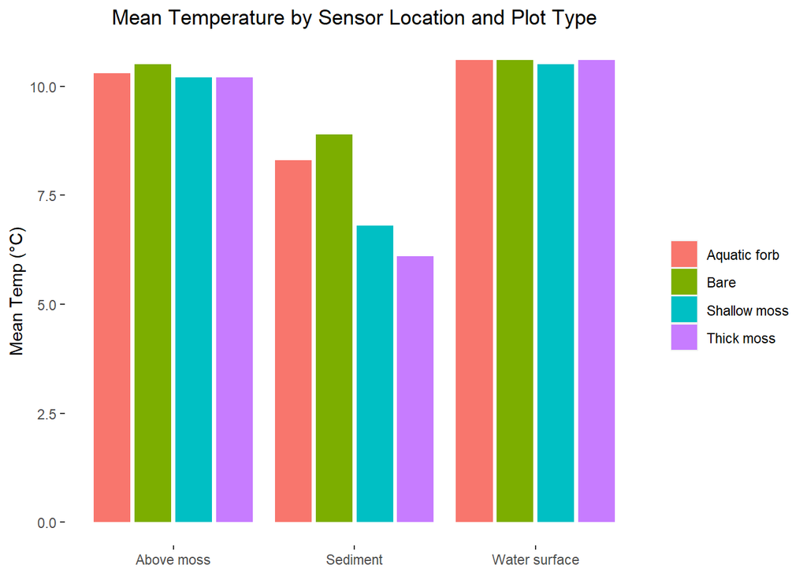

[output not shown]

### Let’s look at the data in more detail.

Here is a plot of the average daily temperature of each iButton from July 19 to August 23.

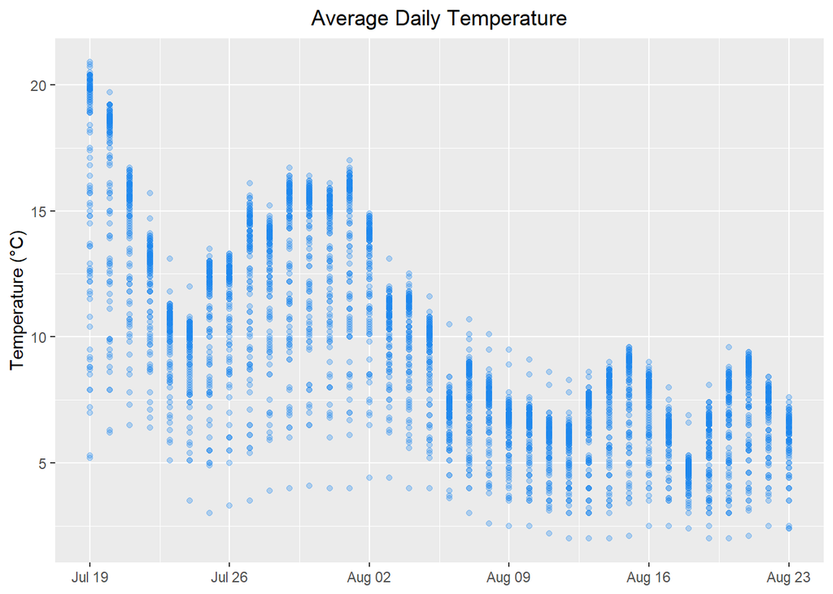

Now we can look at the same data but colored to indicated the location of the temperature sensor: At water surface, sediment surface, or below the water surface, but above the vegetation layer. Two sensors were also placed above the ground to record the ambient air temperature at each site.

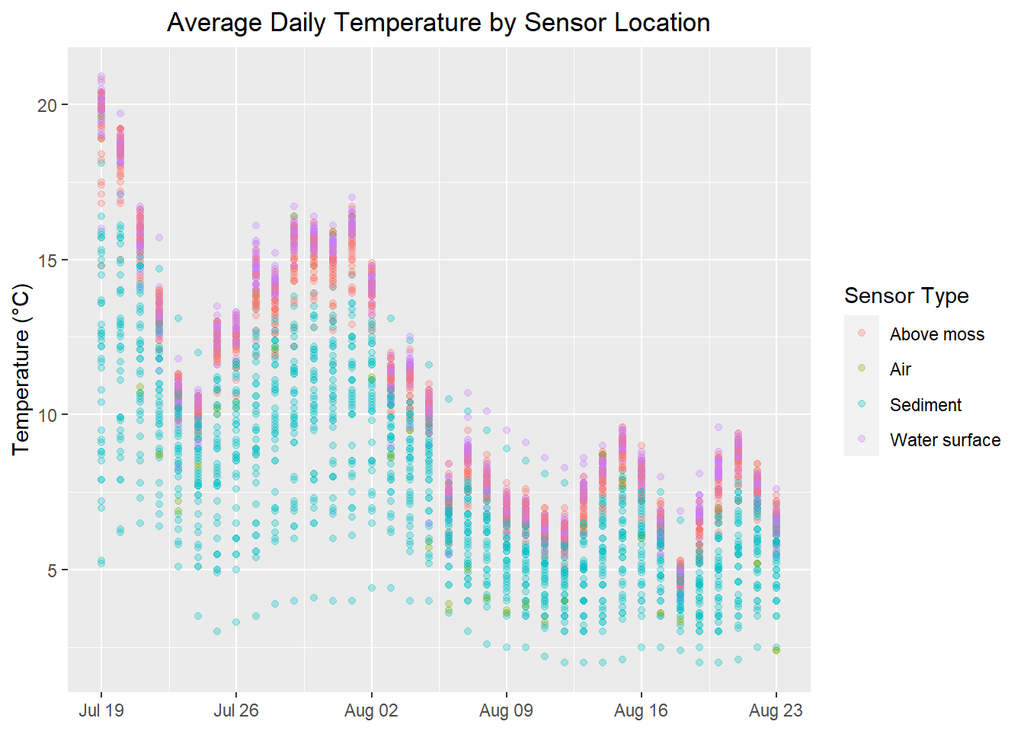

This time we’ll look at the dominant type of aquatic vegetation in the 1-m plot. For example, here the plot shows the average daily temperature data for each sensor location (water surface, sediment surface, above moss layer) in thick moss plots as purple markers. Based onthe previous plot we can assume the coldest temperatures in thick moss plots come from the sensors at the sediment surface, and the warmest temperatures are from the water surface.

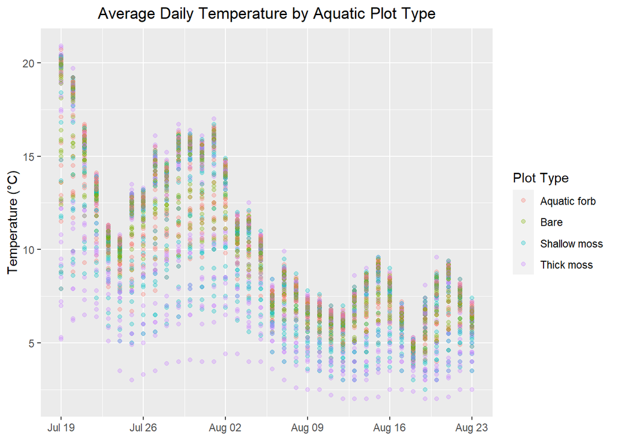

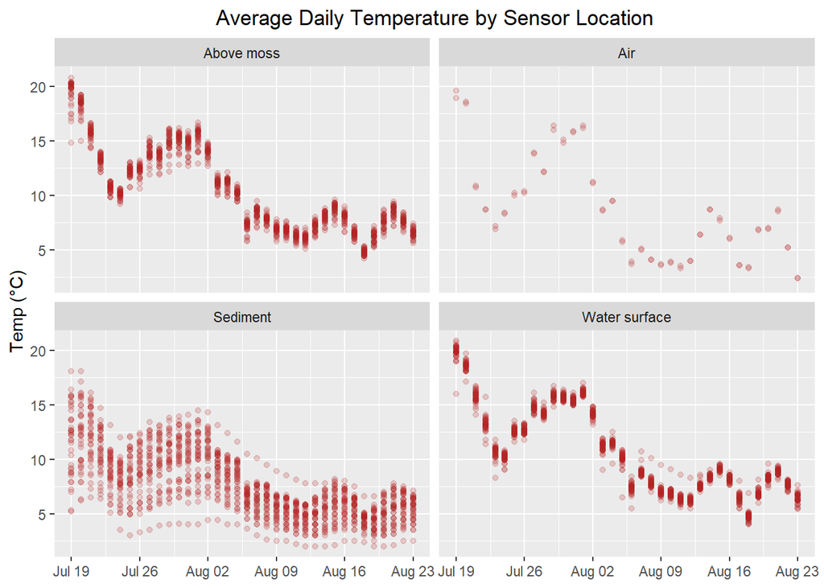

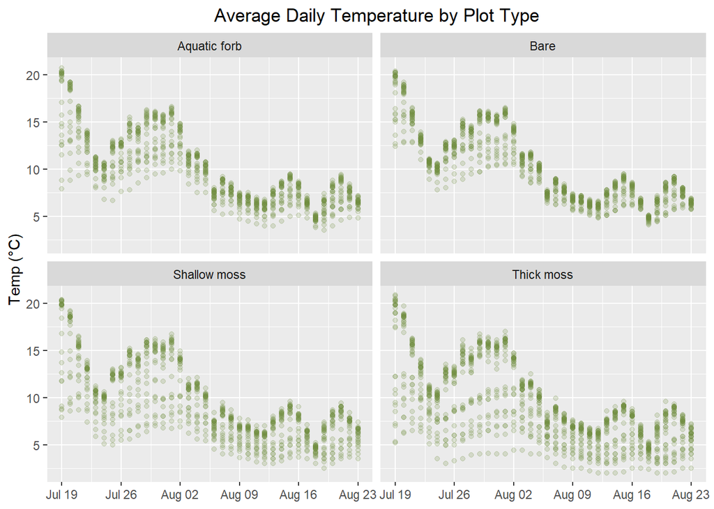

### What’s going on at the sediment surface?

Let’s take a closer look at the differences in temperature at the sediment surface by plot type. As we’ve seen the coldest temperatures are at the pond bottoms are in plots characterized by thick moss.

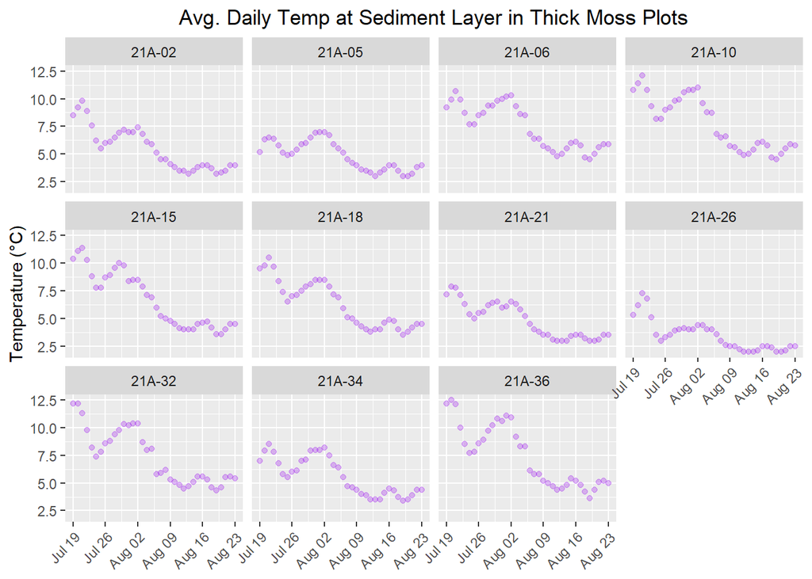

Followed by shallow moss…

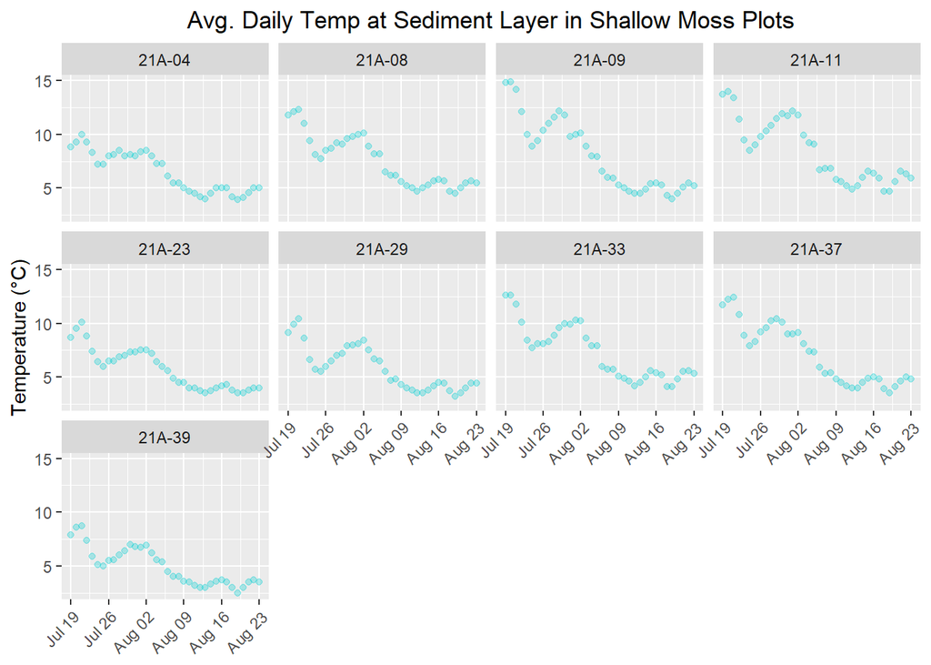

And aquatic forb plots…

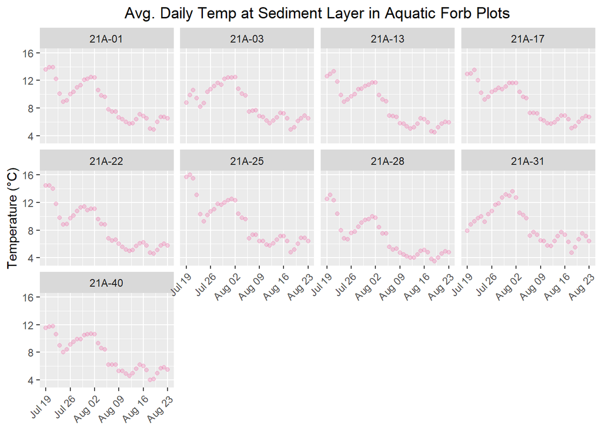

Finally, we observe the warmest temperatures at the pond bottom (sediment surface location) in plots without significant vegetation of any type (bare plots).

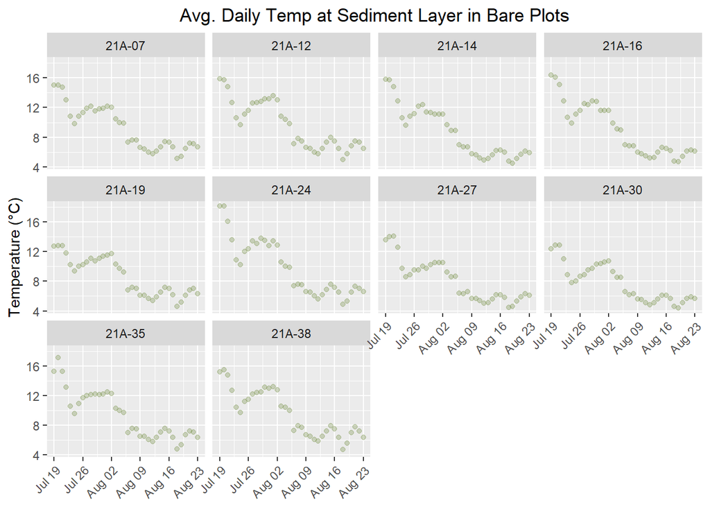